# FigureYa289TILSig

**Author(s)**: Guoqi Li  
**Reviewer(s)**: Ying Ge, Taojun Ye  
**Date**: 2025-12-03

## 1 Academic Citation

If you use this code in your work or research, we kindly request that you cite our publication:

Xiaofan Lu, et al. (2025). FigureYa: A Standardized Visualization Framework for Enhancing Biomedical Data Interpretation and Research Efficiency. iMetaMed. https://doi.org/10.1002/imm3.70005

## 2 需求描述 Requirement description

利用纯化细胞系计算免疫相关指数的计算方法，想学习框里的这个复现方法

I want to learn the replication method in the box for calculating immune related indices using purified cell lines

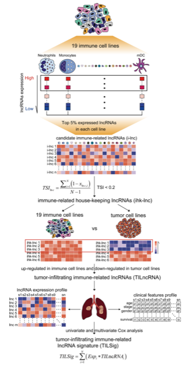

From https://jitc.bmj.com/content/8/1/e000110.long

Figure 1 Strategy for identifying tumor-infiltrating immune-related lncRNA signature (TILSig) in this study. Top 5% expressed long non-coding RNAs (lncRNAs) were obtained as candidate immune-related lncRNAs for each immune cell line. The specificity of expression of a candidate immune-related lncRNA with respect to different immune cell types was calculated using tissue specificity index (TSI). Those housekeeping lncRNAs (hklncRNAs) which are upregulated in immune cell lines and downregulated in non-small cell lung cancer (NSCLC) cell lines were selected as tumor-infiltrating immune-related lncRNAs.

A prognostic signature by focusing tumor-infiltrating immune-related lncRNAs (TILSig) was constructed using the linear combination of the expression values of the prognostic tumor-infiltrating immune-related lncRNAs, weighted by their estimated regression coefficients in the multivariate Cox regression analysis.

## 3 应用场景 Application scenarios

从表达数据鉴定肿瘤免疫浸润相关lncRNA。

Identify tumor immune infiltration related lncRNAs from expression data.

## 4 环境设置 Environment settings

```r
source("install_dependencies.R")
```

[output not shown]

```
##
## Installing DealGPL570 from local file...
## Installing package from local tar.gz file: DealGPL570_0.0.1.tar.gz
```

[output not shown]

```r
# 加载DealGPL570包，用于处理GPL570平台的表达谱数据（Load the DealGPL570 package to process expression profile data from the GPL570 platform）
# 由于所有免疫细胞系的表达谱数据均来自GPL570平台([HG-U133_Plus_2] Affymetrix Human Genome U133 Plus 2.0 Array)，因此这里使用DealGPL570包来处理GPL570平台的表达谱数据。
# Since the expression profile data of all immune cell lines are from the GPL570 platform ([HG-U133_Plus_2] Affymetrix Human Genome U133 Plus 2.0 Array),
# the DealGPL570 package is used here to process the expression profile data from the GPL570 platform.
library(DealGPL570)
library(stringr) # 用于字符串处理（for string processing）
library(sva) # 用于批次效应校正（for batch effect correction）
library(tibble) # 用于数据框操作（for data frame manipulation）
library(dplyr) # 用于数据操作（for data manipulation）
library(tidyverse) # 用于数据处理和可视化（for data processing and visualization）
library(GenomicFeatures) # 用于基因组特征处理（for genomic feature processing）
library(limma) # 用于差异表达分析（for differential expression analysis）
library(survival) # 用于生存分析（for survival analysis）
library(rtracklayer) # 用于基因组数据导入导出（for genomic data import/export）

# 设置环境变量，显示英文报错信息（Set environment variable to display English error messages）
Sys.setenv(LANGUAGE = "en")
# 禁止将字符向量自动转换为因子类型（Disable automatic conversion of character vectors to factors）
options(stringsAsFactors = FALSE)
```

## 5 输入文件 Input file

### 5.1 数据收集 Data collection

文章所使用的大型数据包括19种免疫细胞系表达谱数据，GENECODE注释文件，RefSeq注释文件。 CCLE表达谱数据，TCGA胃癌表达谱数据和临床数据，count数据转换为TPM数据的参考数据集。

The large data used in the article including expression profile data of 19 immune cell lines, GENECODE annotation files, and RefSeq annotation files. The reference dataset for converting CCLE expression profile data, TCGA gastric cancer expression profile data, clinical data, and count data into TPM data.

### 5.2 来自GEO的表达数据处理 Expression data processing from GEO

```r
# 使用DealGPL570处理16个表达谱数据，包含114个细胞系，19种免疫细胞类型
# Process 16 expression profile datasets containing 114 cell lines and 19 immune cell types using DealGPL570
GSE13906 <- DealGPL570(file = "GSE13906_RAW.tar",type = "geneSymbol")
```

```
## Background correcting
## Normalizing
## Calculating Expression
```

```r
# 将symbol列设置为行名（Set the 'symbol' column as row names）
GSE13906 <- column_to_rownames(GSE13906,"symbol")

# 依次处理其余15个GSE数据集（Process the remaining 15 GSE datasets in sequence）
GSE23371 <- DealGPL570(file = "GSE23371_RAW.tar",type = "geneSymbol")
```

```
## Background correcting
## Normalizing
## Calculating Expression
```

```r
GSE23371 <- column_to_rownames(GSE23371,"symbol")

GSE25320 <- DealGPL570(file = "GSE25320_RAW.tar",type = "geneSymbol")
```

```
## Background correcting
## Normalizing
## Calculating Expression
```

```r
GSE25320 <- column_to_rownames(GSE25320,"symbol")

GSE27291 <- DealGPL570(file = "GSE27291_RAW.tar",type = "geneSymbol")
```

```
## Background correcting
## Normalizing
## Calculating Expression
```

```r
GSE27291 <- column_to_rownames(GSE27291,"symbol")

GSE27838 <- DealGPL570(file = "GSE27838_RAW.tar",type = "geneSymbol")
```

```
## Background correcting
## Normalizing
## Calculating Expression
```

```r
GSE27838 <- column_to_rownames(GSE27838,"symbol")

GSE28490 <- DealGPL570(file = "GSE28490_RAW.tar",type = "geneSymbol")
```

```
## Background correcting
## Normalizing
## Calculating Expression
```

```r
GSE28490 <- column_to_rownames(GSE28490,"symbol")

GSE28698 <- DealGPL570(file = "GSE28698_RAW.tar",type = "geneSymbol")
```

```
## Background correcting
## Normalizing
## Calculating Expression
```

```r
GSE28698 <- column_to_rownames(GSE28698,"symbol")

GSE28726 <- DealGPL570(file = "GSE28726_RAW.tar",type = "geneSymbol")
```

```
## Background correcting
## Normalizing
## Calculating Expression
```

```r
GSE28726 <- column_to_rownames(GSE28726,"symbol")

GSE37750 <- DealGPL570(file = "GSE37750_RAW.tar",type = "geneSymbol")
```

```
## Background correcting
## Normalizing
## Calculating Expression
```

```r
GSE37750 <- column_to_rownames(GSE37750,"symbol")

GSE39889 <- DealGPL570(file = "GSE39889_RAW.tar",type = "geneSymbol")
```

```
## Background correcting
## Normalizing
## Calculating Expression
```

```r
GSE39889 <- column_to_rownames(GSE39889,"symbol")

GSE42058 <- DealGPL570(file = "GSE42058_RAW.tar",type = "geneSymbol")
```

```
## Background correcting
## Normalizing
## Calculating Expression
```

```r
GSE42058 <- column_to_rownames(GSE42058,"symbol")

GSE49910 <- DealGPL570(file = "GSE49910_RAW.tar",type = "geneSymbol")
```

```
## Background correcting
## Normalizing
## Calculating Expression
```

```r
GSE49910 <- column_to_rownames(GSE49910,"symbol")

GSE51540 <- DealGPL570(file = "GSE51540_RAW.tar",type = "geneSymbol")
```

```
## Background correcting
## Normalizing
## Calculating Expression
```

```r
GSE51540 <- column_to_rownames(GSE51540,"symbol")

GSE59237 <- DealGPL570(file = "GSE59237_RAW.tar",type = "geneSymbol")
```

```
## Background correcting
## Normalizing
## Calculating Expression
```

```r
GSE59237 <- column_to_rownames(GSE59237,"symbol")

GSE6863 <- DealGPL570(file = "GSE6863_RAW.tar",type = "geneSymbol")
```

```
## Background correcting
## Normalizing
## Calculating Expression
```

```r
GSE6863 <- column_to_rownames(GSE6863,"symbol")

GSE8059 <- DealGPL570(file = "GSE8059_RAW.tar",type = "geneSymbol")
```

```
## Background correcting
## Normalizing
## Calculating Expression
```

```r
GSE8059 <- column_to_rownames(GSE8059,"symbol")

# 修改列名，仅保留GSE开头的GSE样本编号，去除.CEL后缀
# Modify column names to keep only GSE sample IDs starting with "GSE" and remove .CEL suffix
for (i in ls(pattern = "^GSE")) {
  rt <- get(i)
  colnames(rt) <- str_replace_all(colnames(rt),".CEL","")
  assign(i,rt)
}

# 从PMID: 28052254文献的补充材料中（文件名:1-s2.0-S2211124716317090-mmc3.xlsx）提取每个样本对应的细胞类型，整理后的文件命名为Immune_cell_line.txt
# Extract the cell type corresponding to each sample from the supplementary materials of the literature PMID: 28052254
# (file name: 1-s2.0-S2211124716317090-mmc3.xlsx), and name the organized file Immune_cell_line.txt
# 读取注释信息（Read annotation information）
ann <- read.table("Immune_cell_line.txt",header=T,sep="\t",quote="",check.name=F)
# 查看注释信息（View annotation information）
head(ann)
```

```
##              Population Data set Sample ID PubMed ID
## 1      B cell activated  GSE1133  GSM18881  15075390
## 2      B cell activated  GSE1133  GSM18882  15075390
## 3 CD4 T cell activated   GSE1133  GSM18877  15075390
## 4 CD4 T cell activated   GSE1133  GSM18878  15075390
## 5 CD8 T cell activated   GSE1133  GSM18879  15075390
## 6 CD8 T cell activated   GSE1133  GSM18880  15075390
```

```r
# 提取16个数据集的注释信息（按GSE号提取，粗略提取）
# Extract annotation information for 16 datasets (extracted by GSE number, rough extraction)
ann <- ann[which(ann$`Data set`%in%ls(pattern = "^GSE")),]
# 查看各数据集样本数量分布（View the sample count distribution of each dataset）
table(ann$`Data set`)
```

```
##
## GSE13906 GSE23371 GSE25320 GSE27291 GSE27838 GSE28490 GSE28698 GSE28726
##        2        3        4        8        8        5        3       14
## GSE37750 GSE39889 GSE42058 GSE49910 GSE51540 GSE59237  GSE6863  GSE8059
##        8        4        4       26        9       10        3        4
```

```r
# 提取16个数据集中仅在注释中有的免疫细胞系（按GSM号提取，详细提取）
# Extract immune cell lines from 16 datasets that are only present in the annotations (extracted by GSM number, detailed extraction)
for (j in ls(pattern = "^GSE")) {
  rt <- get(j)
  rt <- rt[,which(colnames(rt)%in%ann[which(ann$`Data set`==j),"Sample ID"])]
  assign(j,rt)
}

# 将数据合并（Merge the data）
data <- cbind(GSE13906, GSE23371, GSE25320, GSE27291, GSE27838, GSE28490, GSE28698,
            GSE28726, GSE37750, GSE39889, GSE42058, GSE49910, GSE51540,
            GSE59237, GSE6863, GSE8059)

# 主成分分析查看数据集间批次效应
# Perform principal component analysis to check batch effects between datasets
source("batchPCA.R")
batchPCA(indata = t(scale(t(data))),
         batch = rep(c("GSE13906", "GSE23371", "GSE25320", "GSE27291", "GSE27838", "GSE28490", "GSE28698",
                       "GSE28726", "GSE37750", "GSE39889", "GSE42058", "GSE49910", "GSE51540",
                       "GSE59237", "GSE6863", "GSE8059"),
                     times=c(2,3,4,8,8,5,2,14,8,4,4,26,9,10,3,4)),
         fig.dir = ".",
         PCA.fig.title = "Raw PCA for GEO Immune cell lines",
         #cols =brewer.pal(6, "Set1"),
         showID = F,
         cex = 0.5,
         showLegend =T,
         pos = "bottomright")
# 去除批次效应（Remove batch effects）
batch <- data.frame(batch = rep(c("GSE13906", "GSE23371", "GSE25320", "GSE27291", "GSE27838", "GSE28490", "GSE28698",
                                "GSE28726", "GSE37750", "GSE39889", "GSE42058", "GSE49910", "GSE51540",
                                "GSE59237", "GSE6863", "GSE8059"),
                              times=c(2,3,4,8,8,5,2,14,8,4,4,26,9,10,3,4)))
modcombat <- model.matrix(~1,data = batch)
data_combat <- as.data.frame(ComBat(dat=as.matrix(data),batch=batch$batch,mod=modcombat))
```

```
## Found 52 genes with uniform expression within a single batch (all zeros); these will not be adjusted for batch.
```

```
## Found16batches
```

```
## Adjusting for0covariate(s) or covariate level(s)
```

```
## Standardizing Data across genes
```

```
## Fitting L/S model and finding priors
```

```
## Finding parametric adjustments
```

```
## Adjusting the Data
```

```r
# 将去除批次效应后的整合数据输出（Output the integrated data after batch effect removal）
write.table(data_combat,"data_combat.txt",quote = F,row.names = T,col.names = T,sep = "\t")

# 批次效应校正后的主成分分析（Principal component analysis after batch effect correction）
batchPCA(indata = t(scale(t(data_combat))),
         batch = rep(c("GSE13906", "GSE23371", "GSE25320", "GSE27291", "GSE27838", "GSE28490", "GSE28698",
                       "GSE28726", "GSE37750", "GSE39889", "GSE42058", "GSE49910", "GSE51540",
                       "GSE59237", "GSE6863", "GSE8059"),
                     times=c(2,3,4,8,8,5,2,14,8,4,4,26,9,10,3,4)),
         fig.dir = ".",
         PCA.fig.title = "Combat PCA for GEO",
         #cols =brewer.pal(6, "Set1"),
         showID = F,
         cex = 1,
         showLegend = T,
         pos = "bottomright")
```

### 5.3 提取lncRNA表达谱数据 Extract lncRNA expression profile data

```r
# 提取lncRNA表达谱数据（Extract lncRNA expression profile data）
# 首先是通过GENCODE注释信息提取lncRNA（First, extract lncRNA through GENCODE annotation information）
genecode <- import('gencode.v25.long_noncoding_RNAs.gtf')  # 导入GENCODE数据库的lncRNA的gtf注释文件（Import the gtf annotation file of lncRNA from the GENCODE database）
genecode <- as.data.frame(genecode)  # 转换成数据框便于操作（Convert to a data frame for easy manipulation）
genecode_lncRNA <- unique(genecode$gene_name)  # 去重（Remove duplicates）

# 然后是通过RefSeq注释信息提取lncRNA（Then extract lncRNA through RefSeq annotation information）
refseq <- import('GRCh38_latest_genomic.gff')  # 导入RefSeq数据库的gff注释文件（Import the gff annotation file from the RefSeq database）
refseq <- cbind(ID=refseq$ID, gene=refseq$gene, gene_biotype=refseq$gene_biotype)  # 选择需要的三列（Select the three required columns）
refseq <- as.data.frame(refseq)  # 转换成数据框便于操作（Convert to a data frame for easy manipulation）

refseq_lncRNA1 <- unique(refseq[which(refseq$gene_biotype=="lncRNA"), "gene"])  # 提取基因类型为“lncRNA”的基因（Extract genes with gene type "lncRNA"）
refseq_lncRNA2 <- unique(refseq[grep("NR_", as.character(refseq$ID)), "gene"])  # 提取Refseq ID以NR_开头的基因（Extract genes with Refseq ID starting with "NR_"）
refseq_lncRNA <- intersect(refseq_lncRNA1, refseq_lncRNA2)  # 取二者交集（Take the intersection of the two）

lncRNA <- intersect(genecode_lncRNA, refseq_lncRNA)  # 取GENCODE和RefSeq数据库lncRNA的交集（Take the intersection of lncRNA from GENCODE and RefSeq databases）

# 最后得到lncRNA表达谱数据（Finally, obtain lncRNA expression profile data）
data_lncRNA <- data_combat[which(rownames(data_combat) %in% lncRNA), ]  # 从合并数据中筛选出lncRNA的表达数据（Filter lncRNA expression data from the merged data）

# 输出全部免疫细胞系表达谱数据（Output expression profile data of all immune cell lines）
write.table(data_combat, "expall_114line.txt", col.names = T, row.names = T, sep = "\t", quote = F)
# 输出全部免疫细胞系lncRNA表达谱数据（Output lncRNA expression profile data of all immune cell lines）
write.table(data_lncRNA, "explncRNA_114line.txt", col.names = T, row.names = T, sep = "\t", quote = F)
```

## 6 对每个免疫细胞系的lncRNA进行排序 Sort the lncRNAs of each immune cell line

```r
# 提取lncRNA表达谱数据的免疫细胞系注释信息（Extract annotation information of immune cell lines for lncRNA expression profile data）
ann_114 <- ann[which(ann$`Sample ID` %in% colnames(data_lncRNA)), ]  # 筛选出与lncRNA表达谱样本ID匹配的注释信息（Filter annotations matching lncRNA expression profile sample IDs）
table(ann_114$Population)  # 统计各免疫细胞类型的样本数量（Count sample numbers for each immune cell type）
```

```
##
##             B cell activated        CD4 T cell activated
##                            9                            7
##           CD4 T cell resting        CD8 T cell activated
##                            4                            6
##           CD8 T cell resting    Dendritic cells activated
##                            4                            4
##      Dendritic cells resting                  Eosinophils
##                            6                            2
##     Immature dendritic cells         Mast cells activated
##                            6                            4
##                    Monocytes      Myeloid dendritic cells
##                            6                            4
##                  Neutrophils                 NK activated
##                            7                           11
##                   NK resting                NKT activated
##                            1                            6
## Plasmacytoid dendritic cells               T gamma delta
##                            8                           10
##                  T helper 17
##                            9
```

```r
# 调整表达谱顺序，使得注释信息和表达谱数据的样本顺序一致（Adjust expression profile order to match annotation sample order）
loc <- match(ann_114$`Sample ID`, colnames(data_lncRNA))  # 获取样本ID在表达谱中的位置索引（Get position indices of sample IDs in expression profile）
data_lncRNA <- data_lncRNA[, loc]  # 按注释顺序重排表达谱列（Rearrange expression profile columns by annotation order）

# 处理一个lncRNA对应多个相同免疫细胞系的情况（Handle cases where one lncRNA corresponds to multiple same immune cell lines）
mean_lncRNA <- as.data.frame(t(data_lncRNA))  # 转置数据，使行为细胞系、列为lncRNA（Transpose data: rows=cell lines, columns=lncRNA）
mean_lncRNA$CellType <- ann_114$Population  # 添加细胞类型注释列（Add cell type annotation column）
CellType <- ann_114$Population  # 存储细胞类型向量（Store cell type vector）

# 按细胞类型聚合表达值并计算均值（Aggregate expression values by cell type and calculate mean）
mean_lncRNA <- aggregate(mean_lncRNA, by = list(CellType), FUN = mean)  #
```

[output not shown]

```r
# by=list(CellType)：按CellType列分组（Group by CellType column）
# FUN=mean：对每组计算均值（Calculate mean for each group）

mean_lncRNA$CellType <- NULL  # 删除临时分组列（Remove temporary grouping column）
mean_lncRNA <- column_to_rownames(mean_lncRNA, "Group.1")  # 将分组列设为行名（Set grouping column as row names）
rank_lncRNA <- as.data.frame(t(mean_lncRNA))  # 再次转置，使行为lncRNA、列为细胞类型（Transpose again: rows=lncRNA, columns=cell types）

# 提取19种免疫细胞系中每种细胞系的lncRNA排序结果（Extract lncRNA ranking results for each of 19 immune cell lines）
top_outTab <- data.frame()  # 创建空数据框存储排序结果（Create empty data frame for ranking results）

for (m in c(seq(0.01, 1, 0.01))) {  # 按1%间隔遍历阈值（Traverse thresholds at 1% intervals）
  outTab <- data.frame(ID = 1:(nrow(rank_lncRNA) * m))  # 初始化每行阈值对应的空表（Initialize empty table for each threshold）

  # 对每种免疫细胞系中的lncRNA表达值进行降序排列（Descending sort of lncRNA expression values for each cell line）
  for (i in 1:ncol(rank_lncRNA)) {
    top <- rownames(rank_lncRNA[order(rank_lncRNA[, i], decreasing = T), ])[1:(nrow(rank_lncRNA) * m)]
    # order(decreasing=T)：降序排序（Sort in descending order）
    # [1:(nrow*M)]：取前M%的基因（Take top M% genes）
    outTab[, i] <- top  # 将排序结果存入表中（Store ranking results in table）
  }
  colnames(outTab) <- colnames(rank_lncRNA)  # 设置列名为细胞类型（Set column names as cell types）

  # 方法1：提取19种细胞系的共有lncRNA（交集）（Method 1: Extract common lncRNA across 19 cell lines (intersection)）
  inter <- Reduce(intersect, list(
    v1 = outTab[, 1], v2 = outTab[, 2], v3 = outTab[, 3], v4 = outTab[, 4], v5 = outTab[, 5],
    v6 = outTab[, 6], v7 = outTab[, 7], v8 = outTab[, 8], v9 = outTab[, 9], v10 = outTab[, 10],
    v11 = outTab[, 11], v12 = outTab[, 12], v13 = outTab[, 13], v14 = outTab[, 14], v15 = outTab[, 15],
    v16 = outTab[, 16], v17 = outTab[, 17], v18 = outTab[, 18], v19 = outTab[, 19]
  ))
  # Reduce(intersect, list(...))：对所有细胞系的top基因取交集（Intersect top genes across all cell lines）

  # 方法2：提取19种细胞系的共有lncRNA（并集）（Method 2: Extract common lncRNA across 19 cell lines (union)）
  union <- Reduce(union, list(
    v1 = outTab[, 1], v2 = outTab[, 2], v3 = outTab[, 3], v4 = outTab[, 4], v5 = outTab[, 5],
    v6 = outTab[, 6], v7 = outTab[, 7], v8 = outTab[, 8], v9 = outTab[, 9], v10 = outTab[, 10],
    v11 = outTab[, 11], v12 = outTab[, 12], v13 = outTab[, 13], v14 = outTab[, 14], v15 = outTab[, 15],
    v16 = outTab[, 16], v17 = outTab[, 17], v18 = outTab[, 18], v19 = outTab[, 19]
  ))
  # Reduce(union, list(...))：对所有细胞系的top基因取并集（Union top genes across all cell lines）

  # 合并结果（Merge results）
  union <- data.frame(top_index = rep(m, length(union)), gene = union)  # 构建并集结果表（Build union result table）
  top_outTab <- rbind(union, top_outTab)  # 按行合并结果（Row-wise merge results）

  # （交集方法的代码已注释，如需使用请取消注释下方两行）
  # inter <- data.frame(top_index = rep(m, length(inter)), gene = inter)
  # top_outTab <- rbind(inter, top_outTab)
}

# 结果说明：第一列为阈值（1%到100%），第二列为对应的lncRNA（Result description: 1st column=threshold (1%-100%), 2nd column=corresponding lncRNA）
head(top_outTab)  # 查看结果前几行（View first few rows of results）
```

```
##   top_index      gene
## 1         1     SNHG5
## 2         1     SNHG6
## 3         1     ZFAS1
## 4         1 ARMC2-AS1
## 5         1     SNHG1
## 6         1     SNHG8
```